# Analysing vcf SNP files in R with *VariantAnnotation*

SRE

3 March 2015

# Background

VCF files are a common, useful, and detailed file format for holding genotype variant information (‘Variant Call Format’). It has largely been used in the human genomics space to collect and store variant information from SNPs (most common) to indels and larget structural rearrangements.

A useful source of information in regards to the file format itself can be found here:

http://www.1000genomes.org/wiki/analysis/variant%20call%20format/vcf-variant-call-format-version-41

For now, this will walkthrough some of the methods in which we can load up vcf files into R for quick parsing of their information.

The best way to parse vcf files in R is to use the *VariantAnnotation* package from bioconductor:

http://www.bioconductor.org/packages/release/bioc/html/VariantAnnotation.html

We can get this all setup in R like so

```r
#source("http://bioconductor.org/biocLite.R")
#biocLite("VariantAnnotation")
library(VariantAnnotation)
```

Once installed, we have the ability to quickly parse vcf files to determine what information they hold, how many samples, what types of information / formatting / data they contain using the *scanVcfHeader* command:

```r
scanVcfHeader("Bdis_7geno_test100k.vcf.gz")
```

```
## class: VCFHeader
## samples(7): Bd1-1 Bd21-3_r ... BdTR12c Bd21control
## meta(9): fileformat SnpEffCmd ... samtoolsVersion source
## fixed(1): FILTER
## info(27): AC1 AF ... AC AN
## geno(8): GT DP ... PL SP
```

This quickly goes through the metadata of the vcf file and provides detailed information in regards to the number of samples, information for each variant (info), and information for each genotype call (geno).

In many cases, you may be working with a very large file in which you may want to directly subset the data you pull into R. Before we load any of the data into R, we can specify the exact information we are interested in using *ScanVcfParam*. For instance, we could subset our VCF to only load in the direct genotype calls (“GT” based on the format information) as well as specific genotypes and ranges of data:

```r
param = ScanVcfParam(geno="GT",samples=c('Bd1-1', 'Bd3-1_r','Bd21-3_r'),which=GRanges("Bd1", IRanges(1, 50000)))
```

Note, you can basically setup the loading parameters based on anything in the vcf file. This is just a simple examples. We can then load in our vcf data based on the parameters requested:

```r
vcf=readVcf("Bdis_7geno_test100k.vcf.gz","Bd21Control",param=param)
```

the *readVcf* function wants your file of interest as well as the genome you are working with. You can also load the entire vcf file by just ommitting the param argument in *readVcf*.

- Row information for each variant that is common to all genotype calls such as chromosome, start, stop, ID - *rowData()*
- Information in regards to metadata and methods used for each variant - *header()*
- Genotype information that is recorded uniquly to each variant - *geno()*

```r
vcf
```

```
## class: CollapsedVCF
## dim: 210 3
## rowData(vcf):
##   GRanges with 5 metadata columns: paramRangeID, REF, ALT, QUAL, FILTER
## info(vcf):
##   DataFrame with 27 columns: AC1, AF, AF1, CGT, CLR, DP, DP4, EFF, FQ, ...
## info(header(vcf)):
##          Number Type    Description
##    AC1   1      Float   Max-likelihood estimate of the first ALT allele...
##    AF    A      Float   Allele Frequency, for each ALT allele, in the s...
##    AF1   1      Float   Max-likelihood estimate of the first ALT allele...
##    CGT   1      String  The most probable constrained genotype configur...
##    CLR   1      Integer Log ratio of genotype likelihoods with and with...
##    DP    1      Integer Raw read depth
##    DP4   4      Integer # high-quality ref-forward bases, ref-reverse, ...
##    EFF   .      String  Predicted effects for this variant.Format: 'Eff...
##    FQ    1      Float   Phred probability of all samples being the same
##    G3    3      Float   ML estimate of genotype frequencies
##    HWE   1      Float   Chi^2 based HWE test P-value based on G3
##    IDV   1      Integer Maximum number of reads supporting an indel
##    IMF   1      Float   Maximum fraction of reads supporting an indel
##    INDEL 0      Flag    Indicates that the variant is an INDEL.
##    MDV   1      Integer Maximum number of high-quality nonRef reads in ...
##    MQ    1      Float   RMS Mapping Quality
##    PC2   2      Integer Phred probability of the nonRef allele frequenc...
##    PCHI2 1      Float   Posterior weighted chi^2 P-value for testing th...
##    PR    1      Integer # permutations yielding a smaller PCHI2.
##    PV4   4      Float   P-values for strand bias, baseQ bias, mapQ bias...
##    QBD   1      Float   Quality by Depth: QUAL/#reads
##    QCHI2 1      Integer Phred scaled PCHI2.
##    RPB   1      Float   Read Position Bias
##    UGT   1      String  The most probable unconstrained genotype config...
##    VDB   1      Float   Variant Distance Bias (v2) for filtering splice...
##    AC    .      Integer Allele count in genotypes
##    AN    1      Integer Total number of alleles in called genotypes
## geno(vcf):
##   SimpleList of length 1: GT
## geno(header(vcf)):
##       Number Type   Description
##    GT 1      String Genotype
```

# Header Information

We can see what is in the header of this file:

```r
header(vcf)
```

```
## class: VCFHeader
## samples(7): Bd1-1 Bd21-3_r ... BdTR12c Bd21control
## meta(9): fileformat SnpEffCmd ... samtoolsVersion source
## fixed(1): FILTER
## info(27): AC1 AF ... AC AN
## geno(8): GT DP ... PL SP
```

We can look further into each section as so:

```r
samples(header(vcf))
```

```
## [1] "Bd1-1"       "Bd21-3_r"    "Bd3-1_r"     "Bd30-1"      "Koz-3"
## [6] "BdTR12c"     "Bd21control"
```

# RowData information

The *rowData* information can also be quickly looked at:

```r
head(rowData(vcf))
```

```
## GRanges object with 6 ranges and 5 metadata columns:
##               seqnames       ranges strand | paramRangeID            REF
##                  <Rle>    <IRanges>  <Rle> |     <factor> <DNAStringSet>
##   ss.12514352      Bd1 [1298, 1298]      * |         <NA>              C
##   ss.12514353      Bd1 [1316, 1316]      * |         <NA>              C
##   ss.12514354      Bd1 [1329, 1329]      * |         <NA>              A
##   ss.12514358      Bd1 [1954, 1954]      * |         <NA>              T
##   ss.12514359      Bd1 [1982, 1982]      * |         <NA>              G
##   ss.12514360      Bd1 [2041, 2041]      * |         <NA>              T
##                              ALT      QUAL      FILTER
##               <DNAStringSetList> <numeric> <character>
##   ss.12514352                  T       999        PASS
##   ss.12514353                  A       999        PASS
##   ss.12514354                  C       999        PASS
##   ss.12514358                  A       999        PASS
##   ss.12514359                  C       115        PASS
##   ss.12514360                  G       999        PASS
##   -------
##   seqinfo: 27 sequences from Bd21Control genome
```

We can pull out individual values similar to the header:

```r
ref(vcf)[1:5]
```

```
##   A DNAStringSet instance of length 5
##     width seq
## [1]     1 C
## [2]     1 C
## [3]     1 A
## [4]     1 T
## [5]     1 G
```

```r
qual(vcf)[1:5]
```

```
## [1] 999 999 999 999 115
```

Each of these values may have their own dataframe types (note that `ref(vcf)` returned a “DNAStringSet” while `qual(vcf)` returned a simple numerical vector).

As we parse it apart, it is easy enough to start looking at things:

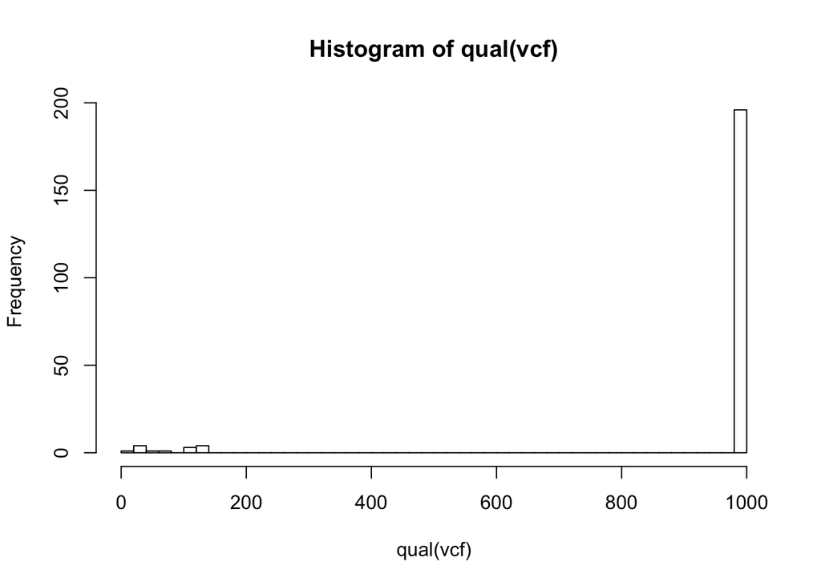

```r
hist(qual(vcf),breaks=50)
```

# Genotype information

For the genotype data, rows are variants and columns are samples. Every piece of genotype data (as described by the format fields) is listed in a matrix:

```r
geno(vcf)
```

```
## List of length 1
## names(1): GT
```

```r
sapply(geno(vcf),class)
```

```
##       GT
## "matrix"
```

We can always go look to see the description of which variables mean what in the header:

```r
geno(header(vcf))
```

```
## DataFrame with 8 rows and 3 columns
##         Number        Type
##    <character> <character>
## GT           1      String
## DP           1     Integer
## DV           1     Integer
## FT           1      String
## GL           3       Float
## GQ           1     Integer
## PL           G     Integer
## SP           1     Integer
##                                         Description
##                                         <character>
## GT                                         Genotype
## DP                             # high-quality bases
## DV               # high-quality non-reference bases
## FT                            Genotype-level filter
## GL Likelihoods for RR,RA,AA genotypes (R=ref,A=alt)
## GQ                                 Genotype Quality
## PL        List of Phred-scaled genotype likelihoods
## SP                 Phred-scaled strand bias P-value
```

So here, we could start pulling out whatever genotype information we want into a matrix:

```r
genotypes=geno(vcf)$GT
head(genotypes)
```

```
##             Bd1-1 Bd3-1_r Bd21-3_r
## ss.12514352 "0/0" "."     "0/1"
## ss.12514353 "0/0" "."     "0/1"
## ss.12514354 "0/0" "."     "0/1"
## ss.12514358 "0/0" "."     "0/1"
## ss.12514359 "0/0" "."     "0/0"
## ss.12514360 "0/0" "."     "0/1"
```

# Information information

Info data is unique to each variant, but the same across all samples:

```r
info(vcf)[1:4,1:5]
```

```
## DataFrame with 4 rows and 5 columns
##                   AC1            AF       AF1         CGT       CLR
##             <numeric> <NumericList> <numeric> <character> <integer>
## ss.12514352        NA         0.357        NA          NA        NA
## ss.12514353        NA         0.071        NA          NA        NA
## ss.12514354        NA         0.357        NA          NA        NA
## ss.12514358        NA         0.357        NA          NA        NA
```